# Data Exploration

Raunak Advani

2022-12-03

# Data Exploration in R

Data exploration is a vital process in the data science field. It is the first step in a data science project, and involves the utilization of data visualization tools and multiple statistical techniques to discover data characteristics and notice initial patterns.

During data exploration, or EDA (Exploratory Data Analysis), raw data is typically reviewed with a combination of automated data-exploration techniques to visually explore the data set, look for similarities, outliers, and patters. This helps in identifying relationships between different variables.

```r
library("dplyr")
library(tidyverse) # import necessary packages
library(readr)
```

```r
getwd()
```

```
## [1] "/Users/raunakadvani/anly-501-project-raunakadvani2410/codes/data-exploring"
```

```r
df <- read.csv("../../data/clean-data/Fredapi_clean.csv")
```

```r
head(df) # visualize the first few rows of our record dataframe
```

```
##   X       date gdp_value unemployment_value fed_funds_value recession
## 1 1 1990-01-01  5872.701                5.3            8.25         0
## 2 2 1990-04-01  5960.028                5.3            8.24         0
## 3 3 1990-07-01  6015.116                5.7            8.16         1
## 4 4 1990-10-01  6004.733                6.1            7.74         1
## 5 5 1991-01-01  6035.178                6.6            6.43         1
## 6 6 1991-04-01  6126.862                6.8            5.86         0
```

Now, let’s create some plots to see if there are any noticeable patterns or outliers in our data.

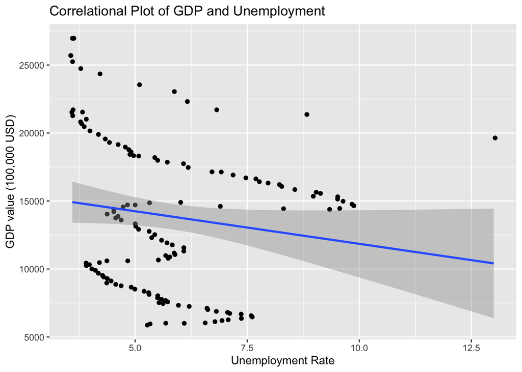

```r
q <- ggplot(df, aes(x=unemployment_value, y=gdp_value)) +
  labs(title = "Correlational Plot of GDP and Unemployment")
q + geom_jitter() + geom_smooth(method="lm", span = 0.2) + xlab("Unemployment Rate") + ylab("GDP value (100,000 USD)")
```

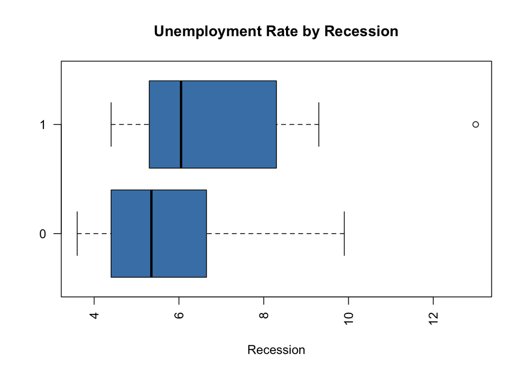

```r
q <- boxplot(df$unemployment_value ~ df$recession, las = 2, horizontal = TRUE,
        col = 'steelblue',
        main = 'Unemployment Rate by Recession',
        xlab = "Recession",
        ylab = NULL)
```

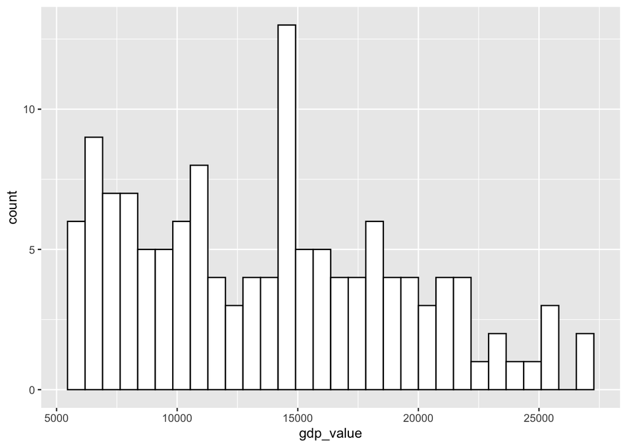

```r
#gdp_int <- as.integer(df['gdp_value'])
p<-ggplot(df, aes(x=gdp_value)) +
  geom_histogram(color="black", fill="white")
p
```

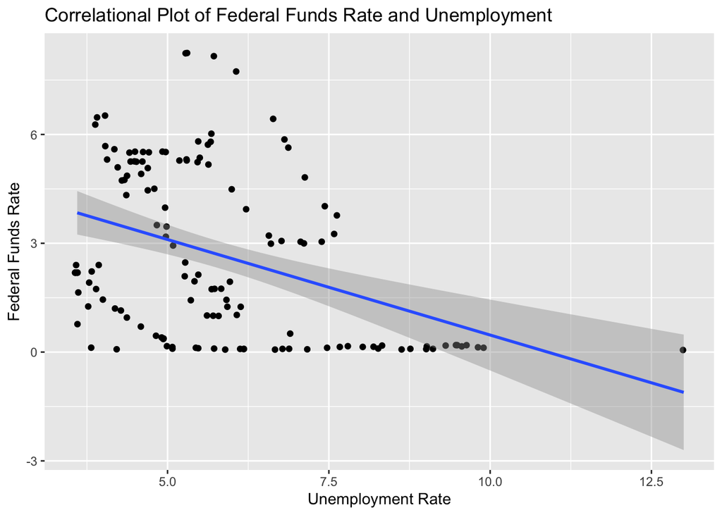

```r
q <- ggplot(df, aes(x=unemployment_value, y=fed_funds_value)) +
  labs(title = "Correlational Plot of Federal Funds Rate and Unemployment")
q + geom_jitter() + geom_smooth(method="lm", span = 0.2) + xlab("Unemployment Rate") + ylab("Federal Funds Rate")
```

Again, we can see the relationship between the interest rates and unemployment rate. This plot shows us a very weak linear relationship, signifying higher unemployment rates when the interest rates are lower. This doesn’t make complete sense to me, as when interest rates are low, people are investing more and companies are spending and thus hiring more, which would lead to a lower unemployment rate. However, this relationship is extremely weak, so it is hard to establish a correlation between the two variables solely based on this plot.

# News API Sentiment Analysis from Vader

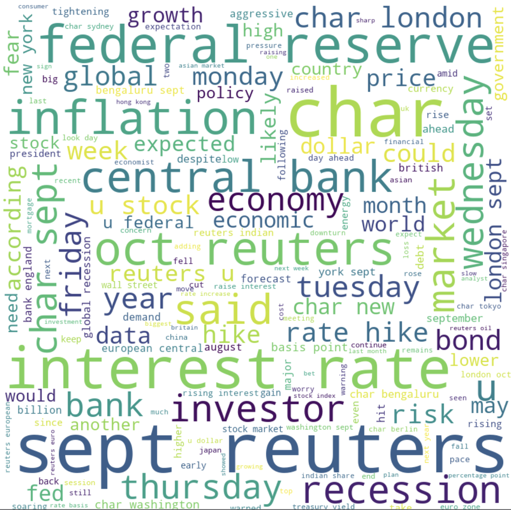

Word Cloud

The above plot is the word cloud from my News API, using Vader Sentiment Analysis. We can see that words such as ‘economy’, ‘investor’, ‘interest rate’, ‘inflation’, and others are quite common in the news, as all of them are terms related to economics and recessions.